# Medidas de Tendencia Central

[Christian Isaí Morales Arteaga](https://arteagachristian.github.io)

Estadística 2022-2, [Facultad de economía](http://www.economia.unam.mx/)

2/3/2022

### 1. ¿Qué son las medidas de tendencia central? 🤔

> Definición: “Las **medidas de tendencia central** (moda,media y mediana), **parámetro de tendencia central** o **medida de centralización** es un número ubicado hacia el centro de la distribución de los valores de una serie de observaciones (medidas), en la que se encuentra ubicado el conjunto de los datos. Las medidas de tendencia central más utilizadas son: media, mediana u moda. Cuando se hace referencia únicamente a la posición de estos parámetros dentro de la distribución, independientemente de que esté más o menos centrada, se habla de estas medidas como **medidas de posición**”.

[Wikipedia 2022 💻](https://es.wikipedia.org/wiki/Medidas_de_tendencia_central)

Para este ejemplo, primero generaremos una serie de **100** números aleatorios entre **1** y **20** mediante la función `sample`. El argumento `TRUE` nos permitirá generar una muestra con remplazo:

```r
numeros <- sample(1:20, 100, TRUE)
numeros
```

```
##   [1] 12 13 15  1  9 12  9 19  9  7 10 16 13  5  8 17 20 10 11  2 13  5 14  6  1
##  [26]  4  2 18  2  6  6  7  9  5 17 18 18  9  3 16 15 18 18 20 18  9 20  9 19  3
##  [51] 18 20 13  2 16  6 15 18  8 14  3 14 17 19 10 16 13  6  4  9 12 11  3  2  2
##  [76] 10 14  8 13 16  1  7  8  9  4 10 10  9  7  9  7  5  7 20 16 19  4  2  5 14
```

### 2. Mediana 📍

> Definición: “La **mediana** es el valor medio de una secuencia ordenada de datos. Si no hay empates, la mitad de las observaciones serán menores y la otra mitad serán mayores. La mediana no se ve afectada por ninguna observación extrema de una serie de datos. Por tanto, siempre que esté presente una observación extrema es apropiado usar la mediana en vez de la media para describir una serie de datos”.

[Aprendiendo administración 💻](https://aprendiendoadministracion.com/medidas-de-tendencia-central-media-mediana-moda-rango-y-eje-medio/)

Para obtener la **mediana**, podemos ordenar los `numeros` de menor a mayor, **el número que esté en medio de la muestra será la mediana**. Si utilizamos R, se puede hacer el cálculo de la **mediana** con la función `median`:

```r
mediana <- median(numeros)
mediana
```

```
## [1] 10
```

### 3. Media 🧮

> Definición: “La **media aritmética** es el promedio o medición de tendencia central de uso más común. Se calcula sumando todas las observaciones de una serie de datos y luego dividiendo el total entre el número de elementos involucrados”.

[Aprendiendo administración 💻](https://aprendiendoadministracion.com/medidas-de-tendencia-central-media-mediana-moda-rango-y-eje-medio/)

$$Media ={\frac {1}{n}}\sum _{i=1}^{n}a_{i}={\frac {a_{1}+a_{2}+\cdots +a_{n}}{n}}$$

Si usamos R, podemos obtener la media de una muestra si utlilizamos la función **mean**:

```r
media <- mean(numeros)
media
```

```
## [1] 10.51
```

### 4. Moda 📊

> Definición: “La **moda** o **modo** es el valor de una serie de datos que aparece con más frecuencia. Se obtiene fácilmente de una clasificación ordenada. A diferencia de la media aritmética, la moda no se ve afectada por la ocurrencia de los valores extremos”.

[Aprendiendo administración 💻](https://aprendiendoadministracion.com/medidas-de-tendencia-central-media-mediana-moda-rango-y-eje-medio/)

Podemos saber cuál es la **frecuencia** (número de veces que aparece un elemento en una muestra) de cada número si dibujamos un **histograma** con la función `hist`, **aquel elemento con mayor frecuencia será la moda**:

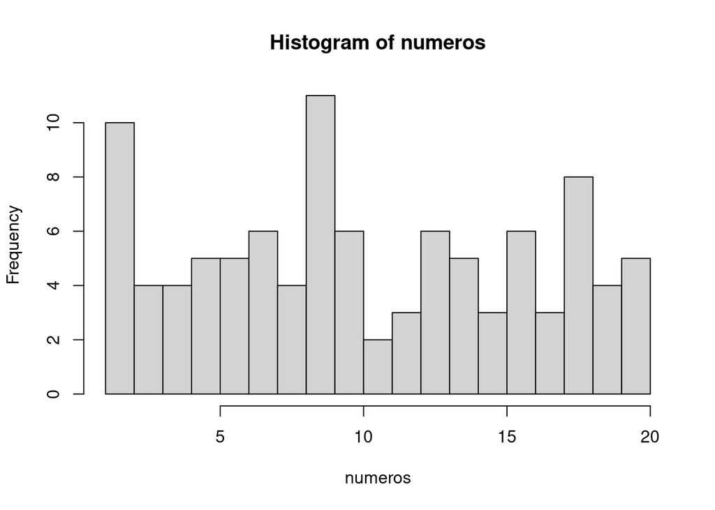

```r
# El argumento breaks nos permite dividir en histograma en las partes que queramos
hist(numeros, breaks = 20)
```

Para obtener un resultado con más precisión, podemos obtener la **moda** si generamos una **tabla de frecuencias** con la función `table` y la función `data.frame`, **aquel elemento con mayor frecuencia será la moda**:

```r
tabla.frecuencias <- data.frame(table(numeros))
tabla.frecuencias
```

```
##    numeros Freq
## 1        1    3
## 2        2    7
## 3        3    4
## 4        4    4
## 5        5    5
## 6        6    5
## 7        7    6
## 8        8    4
## 9        9   11
## 10      10    6
## 11      11    2
## 12      12    3
## 13      13    6
## 14      14    5
## 15      15    3
## 16      16    6
## 17      17    3
## 18      18    8
## 19      19    4
## 20      20    5
```

### 5. Ejercicio 👩‍💻👨‍💻✍

Aplica lo que aprendiste, obten la **mediana**, **media** y **moda** de la siguiente muestra de números:

```r
# Con la función seq, creamos una secuencia de 1 a 10 en intervalos de 0.1 en 0.1
secuencia <- seq(1, 10, 0.1)
muestra <- sample(secuencia, 100, TRUE)
muestra
```

```
##   [1] 1.8 4.6 9.2 5.0 9.7 5.6 9.4 1.2 8.1 1.6 5.8 7.3 1.5 7.4 1.3 9.8 1.5 6.3
##  [19] 9.6 5.8 4.7 8.2 5.4 6.8 9.7 1.3 1.4 5.2 6.2 8.8 5.2 3.1 3.1 7.3 5.3 8.2
##  [37] 3.3 6.2 7.8 1.1 6.6 9.6 5.7 7.8 8.9 3.9 6.9 1.3 4.7 8.3 9.8 9.4 9.2 7.3
##  [55] 1.0 8.2 9.7 7.3 7.1 1.2 6.8 1.8 7.6 7.3 2.7 9.8 5.1 9.7 4.3 2.0 3.9 9.8
##  [73] 8.3 8.0 4.9 8.9 7.0 6.6 4.6 3.6 8.0 6.1 7.9 1.6 9.9 8.3 7.9 7.9 5.2 7.7
##  [91] 1.6 1.0 2.8 9.2 7.4 5.1 5.4 8.2 3.5 6.5
```

##### Mediana

```r
mediana.muestra <- median(muestra)
mediana.muestra
```

```
## [1] 6.55
```

##### Media

```r
media.muestra <- mean(muestra)
media.muestra
```

```
## [1] 5.986
```

##### Moda

```r
tabla.moda <- data.frame(table(muestra))
tabla.moda
```

```
##    muestra Freq
## 1        1    2
## 2      1.1    1
## 3      1.2    2
## 4      1.3    3
## 5      1.4    1
## 6      1.5    2
## 7      1.6    3
## 8      1.8    2
## 9        2    1
## 10     2.7    1
## 11     2.8    1
## 12     3.1    2
## 13     3.3    1
## 14     3.5    1
```

[output cut: 41 more lines]

💻[Código disponible en RStudio Cloud](https://rstudio.cloud/project/3671022)💻